# Auteur: Julien MAKSOUD - MS BGD

```python
import time
import requests
from bs4 import BeautifulSoup
from random import randint
import pandas as pd
from lxml import etree
import numpy as np
import matplotlib.pyplot as plt
import urllib
import re
import os,glob
from scipy.ndimage.filters import uniform_filter1d
import warnings
warnings.filterwarnings('ignore')
# options d'affichage
pd.set_option("display.min_rows", 16)

start = time.time()
```

## Chargement des fichiers Excels de position

```python
import requests

r = requests.get('https://www.vendeeglobe.org/fr/classement')
r.status_code
```

```
200
```

```python
url = 'https://www.vendeeglobe.org/fr/classement'
content = requests.get(url).content.decode('utf-8')
soup = BeautifulSoup(content, 'html.parser')
# print(soup.prettify())
```

```python
## NOM DU FICHIER ACTUEL

file_url = 'https://www.vendeeglobe.org' + str(soup.find('a', class_="rankings__download").attrs['href'])
filename = (soup.find('a', class_="rankings__download").attrs['href'])[32:]

file_url
```

```
'https://www.vendeeglobe.org/download-race-data/vendeeglobe_20201130_170000.xlsx'
```

```python
# IDENTIFIER TOUS LES NOMS DE FICHIERS XLS DISPONIBLES. Noms sont composés de date et heure, donc il suffit de
# les retrouver et reconstruire le nom complet puis les ouvrir directement
contents_re = re.findall('\"(.*?)\"', str(soup.findAll('select', class_ ='form__input m--select onsubmit-rank')))
contents_re = contents_re[3:]

file_urlall = []
# ETABLISSEMENT DE TOUS LES NOMS DES FICHIERS EXCELS SUR LE SITE
for i in contents_re:
    url_full = str(file_url[:59] + str(i) + '.xlsx')
#     filenameall = str(i) + '.xlsx'
    file_urlall.append(url_full)
#     urllib.request.urlretrieve(file_urlall, filenameall)
```

## Prétraitement des données

##### Fonction de conversion des lat / long en décimales

```python
# SOURCE : https://gist.github.com/chrisjsimpson/076a82b51e8540a117e8aa5e793d06ec

def dms2dec(dms_str):

    dms_str = re.sub(r'\s', '', dms_str)

    sign = -1 if re.search('[swSW]', dms_str) else 1

    numbers = [*filter(len, re.split('\D+', dms_str, maxsplit=4))]

    degree = numbers[0]
    minute = numbers[1] if len(numbers) >= 2 else '0'
    second = numbers[2] if len(numbers) >= 3 else '0'
    frac_seconds = numbers[3] if len(numbers) >= 4 else '0'

    second += "." + frac_seconds
    return sign * (int(degree) + float(minute) / 60 + float(second) / 3600)
```

##### Fonction de chargement et prétraitement des infos de course

```python
def load_excel(name):

    df = pd.read_excel(name,header=[3,4])
#     print('lecture du fichier : ' , name)
    df = df.drop(df.columns[0],axis=1)
    df = df.drop(columns=['Depuis 30 minutes\nSince 30 minutes','Depuis 24 heures\nSince 24 hours'],level=0)

    df = df[:32]
    df.columns = ['Rang','Nat/Voile','Skipper/Bateau','Heure FR','Latitude','Longitude','Cap','Vitesse','VMG','Distance','DTF','DTL']
    df[['Skipper','bateau']] = df['Skipper/Bateau'].str.rsplit('\n', n=1, expand=True)
    df = df.drop(columns=['Skipper/Bateau'])
    df = df.drop(columns=['bateau'])

    df['Latitude'] =df['Latitude'].fillna("46°29.34'N")  # pour les NaN du début de course, on met latitude des sables d'Olonne
    df['Longitude'] = df['Longitude'].fillna("01°49.44'W")  # pareil pour longitude
    df['Heure FR'] = df['Heure FR'].fillna('11:59 FR')  # 11:59 pour éviter le coup du midi/minuit...
    df['Cap'] = df['Cap'].fillna('0') # cap mis à 0 au début
    df['Vitesse'] = df['Vitesse'].fillna('0')  # vitesse = 0 quand manquante au début de course
    df['VMG'] = df['VMG'].fillna('0') # VMG mise à 0 quand manquante au début de la course
    df['DTL'] = df['DTL'].fillna('0') # distance au premier à 0 quand data manquante
    df['DTF'] = df['DTF'].fillna('24296') # longueur de la course en nm
    df['Rang'] = df['Rang'].str.replace('NL','32') # dans les premiers fichiers, on retrouve NL au lieu du rang des derniers
    df['Rang'] = df['Rang'].fillna('1').astype(int) # tout le monde commence premier par défaut...
    df['Distance'] = df['Distance'].fillna('0') # distance parcourue à 0 au début
    df['Heure FR'] = df['Heure FR'].astype(str).str.rsplit(' ',n=1  ,expand=True)[0]  # isolation des chiffres de l'heure
    df['Date'] = (name[-20:-12] + df['Heure FR']).str.replace(':','') # date extraite du nom de l'excel
    df['Date'] = pd.to_datetime(df['Date'],format='%Y%m%d%H%M') # construction de la colonne date/heure
    df = df.drop(columns=['Heure FR']) # suppression de colonne heure
    df['Vitesse'] = df['Vitesse'].str.rsplit(' ',n=0,expand=True)[0].astype(float) # suppression de l'unité et conversion en float
    df['VMG'] = df['VMG'].str.rsplit(' ',n=0,expand=True)[0].astype(float) # suppression de l'unité et conversion en float
    df['Distance'] = df['Distance'].str.rsplit(' ',n=0,expand=True)[0].astype(float) # suppression de l'unité et conversion en float
    df['DTF'] = df['DTF'].str.rsplit(' ',n=0,expand=True)[0].astype(float) # suppression de l'unité et conversion en float
    df['DTL'] = df['DTL'].str.rsplit(' ',n=0,expand=True)[0].astype(float) # suppression de l'unité et conversion en float
    df['Cap'] = df['Cap'].str.replace('°', '').astype(float) # suppression de l'unité et conversion en float
    df['Nat/Voile'] = df['Nat/Voile'].str.replace('\n','') # espace à la place de retour chariot

    df['Latitude'] = df['Latitude'].apply(dms2dec).astype(float)   # application de la fonction de la case du dessus
    df['Longitude'] = df['Longitude'].apply(dms2dec).astype(float)   # application de la fonction de la case du dessu

#     df['Latitude']=df['Latitude'].astype(float)
#     df['Longitude']=df['Longitude'].astype(float)

    df = df[['Rang','Date','Skipper','Latitude','Longitude','Cap','Vitesse','VMG','Distance','DTF','DTL','Nat/Voile']]
    return df
```

##### Création du dataframe

```python
# df_course = pd.concat([load_excel(filename) for filename in filenames])
df_course = pd.concat([load_excel(fileurl) for fileurl in file_urlall])

df_course = df_course.sort_values('Date')
```

```python
df_course.head()
```

|  | Rang | Date | Skipper | Latitude | Longitude | Cap | Vitesse | VMG | Distance | DTF | DTL | Nat/Voile |
| --- | --- | --- | --- | --- | --- | --- | --- | --- | --- | --- | --- | --- |
| 31 | 1 | 2020-11-08 11:59:00 | Maxime Sorel | 46.492778 | -1.828889 | 0.0 | 0.0 | 0.0 | 0.0 | 24296.0 | 0.0 | FRA 53 |
| 31 | 32 | 2020-11-08 11:59:00 | Charlie Dalin | 46.492778 | -1.828889 | 0.0 | 0.0 | 0.0 | 0.0 | 24296.0 | 0.0 | FRA 79 |
| 0 | 1 | 2020-11-08 11:59:00 | Charlie Dalin | 46.492778 | -1.828889 | 0.0 | 0.0 | 0.0 | 0.0 | 24296.0 | 0.0 | FRA 79 |
| 1 | 1 | 2020-11-08 11:59:00 | Sébastien Simon | 46.492778 | -1.828889 | 0.0 | 0.0 | 0.0 | 0.0 | 24296.0 | 0.0 | FRA 4 |
| 2 | 1 | 2020-11-08 11:59:00 | Clarisse Cremer | 46.492778 | -1.828889 | 0.0 | 0.0 | 0.0 | 0.0 | 24296.0 | 0.0 | FRA 30 |

##### Chargement des Caractéristiques des bateaux

```python
url = 'https://www.vendeeglobe.org/fr/glossaire'
content = requests.get(url).content.decode('utf-8')
soup = BeautifulSoup(content, 'html.parser')

### CHARGEMENT DES INFOS DES BATEAUX

liste_bateaux=[]
for boat in soup.findAll("div",{'class':['boats-list__popup mfp-hide']}):
       bateau={}
       try:
               for i in range(0,14):
                   clef = boat.findAll('li')[i].text.split(":")[0]
                   valeur = boat.findAll('li')[i].text.split(":")[1]
                   bateau[clef] = valeur
               liste_bateaux.append(bateau)

       except IndexError:
               try:
                   for i in range(0,13):
                       clef = boat.findAll('li')[i].text.split(":")[0]
                       valeur = boat.findAll('li')[i].text.split(":")[1]
                       bateau[clef] = valeur
                   liste_bateaux.append(bateau)

               except IndexError:
                   for i in range(0,12):
                       clef = boat.findAll('li')[i].text.split(":")[0]
                       valeur = boat.findAll('li')[i].text.split(":")[1]
                       bateau[clef] = valeur
                   liste_bateaux.append(bateau)

df_voiliers=pd.DataFrame(liste_bateaux)

### CHARGEMENT DES NOMS DES SKIPPERS DE LA MEME PAGE

list_names = []
for skip in soup.findAll("span",{'class':["boats-list__skipper-name"]}):
    list_names.append(str(skip)[39:-7])
```

##### Prétraitement du DataFrame créé à partir du parsing

```python
df_voiliers['Skipper']=list_names
df_voiliers['Skipper'] = df_voiliers['Skipper'].str.title()
df_voiliers.columns = ['Numéro de voile', 'Anciens noms du bateau', 'Architecte',
       'Chantier', 'Date de lancement', 'Longueur', 'Largeur',
       'Tirant', 'Déplacement (poids)', 'Nombre de dérives',
       'Hauteur mat en m', 'Voile quille', 'Surface de voiles au près en m2',
       'Surface de voiles au portant en m2', 'Skipper']

df_voiliers = df_voiliers[['Skipper','Déplacement (poids)','Nombre de dérives','Hauteur mat en m','Surface de voiles au près en m2',
       'Surface de voiles au portant en m2']]
df_voiliers['Hauteur mat en m'] = df_voiliers['Hauteur mat en m'].str.rsplit(' ',n=0,expand=True)[1].str.replace(',','.').str.replace('m','').astype(float)
df_voiliers['Surface de voiles au près en m2'] = df_voiliers['Surface de voiles au près en m2'].str.rsplit(' ',n=0,expand=True)[1].astype(float)
df_voiliers['Surface de voiles au portant en m2']=df_voiliers['Surface de voiles au portant en m2'].str.rsplit(' ',n=0,expand=True)[1].astype(float)
df_voiliers['Foils'] = df_voiliers['Nombre de dérives'].map({' 2 asymétriques':'0' , ' 2' : '0', ' foiler':'1', ' foils':'1'}).astype(int)
df_voiliers = df_voiliers.drop(columns=['Nombre de dérives'])
df_voiliers['Déplacement (poids)'] = df_voiliers['Déplacement (poids)'].str.replace('nc','NaN').str.replace('NC','NaN').str.replace(',','.').str.replace("[^0-9.Na]", "").astype(float)
df_voiliers['Déplacement (poids)'] = df_voiliers['Déplacement (poids)'].fillna(value = df_voiliers['Déplacement (poids)'].mean())

df_voiliers.iloc[11,0]='Samantha Davies'

df_voiliers
```

|  | Skipper | Déplacement (poids) | Hauteur mat en m | Surface de voiles au près en m2 | Surface de voiles au portant en m2 | Foils |
| --- | --- | --- | --- | --- | --- | --- |
| 0 | Fabrice Amedeo | 7.00000 | 29.0 | 320.0 | 570.0 | 1 |
| 1 | Romain Attanasio | 9.00000 | 28.0 | 280.0 | 560.0 | 0 |
| 2 | Alexia Barrier | 9.00000 | 29.0 | 260.0 | 580.0 | 0 |
| 3 | Yannick Bestaven | 8.00000 | 29.0 | 310.0 | 550.0 | 1 |
| 4 | Jérémie Beyou | 8.00000 | 29.0 | 320.0 | 600.0 | 1 |
| 5 | Arnaud Boissières | 7.90000 | 29.0 | 300.0 | 610.0 | 1 |
| 6 | Louis Burton | 7.60000 | 28.0 | 300.0 | 600.0 | 1 |
| 7 | Didac Costa | 8.90000 | 26.0 | 240.0 | 470.0 | 0 |
| 8 | Manuel Cousin | 9.00000 | 28.5 | 270.0 | 560.0 | 0 |
| 9 | Clarisse Cremer | 7.70000 | 29.0 | 340.0 | 570.0 | 0 |
| 10 | Charlie Dalin | 8.00000 | 29.0 | 350.0 | 560.0 | 1 |
| 11 | Samantha Davies | 7.80000 | 27.0 | 300.0 | 600.0 | 1 |
| 12 | Sébastien Destremau | 8.50000 | 29.0 | 250.0 | 650.0 | 0 |
| 13 | Benjamin Dutreux | 8.00000 | 29.0 | 300.0 | 700.0 | 0 |
| 14 | Kevin Escoffier | 8.13871 | 27.4 | 300.0 | 600.0 | 1 |
| 15 | Clément Giraud | 8.50000 | 29.0 | 300.0 | 620.0 | 0 |
| 16 | Pip Hare | 9.00000 | 29.0 | 300.0 | 580.0 | 0 |
| 17 | Boris Herrmann | 7.60000 | 29.0 | 290.0 | 490.0 | 1 |
| 18 | Ari Huusela | 8.50000 | 28.0 | 270.0 | 580.0 | 0 |
| 19 | Isabelle Joschke | 7.70000 | 27.0 | 300.0 | 650.0 | 1 |
| 20 | Jean Le Cam | 8.00000 | 28.0 | 300.0 | 620.0 | 0 |
| 21 | Stéphane Le Diraison | 8.50000 | 28.0 | 300.0 | 550.0 | 1 |
| 22 | Miranda Merron | 8.50000 | 28.0 | 330.0 | 600.0 | 0 |
| 23 | Giancarlo Pedote | 8.00000 | 29.0 | 300.0 | 600.0 | 1 |
| 24 | Alan Roura | 8.13871 | 27.0 | 290.0 | 580.0 | 1 |
| 25 | Thomas Ruyant | 8.00000 | 29.0 | 350.0 | 560.0 | 1 |
| 26 | Damien Seguin | 8.50000 | 29.0 | 350.0 | 610.0 | 0 |
| 27 | Kojiro Shiraishi | 8.00000 | 29.0 | 320.0 | 580.0 | 1 |
| 28 | Sébastien Simon | 8.00000 | 29.0 | 260.0 | 600.0 | 1 |
| 29 | Maxime Sorel | 7.70000 | 29.0 | 365.0 | 700.0 | 0 |
| 30 | Alex Thomson | 7.70000 | 29.0 | 330.0 | 630.0 | 1 |
| 31 | Armel Tripon | 7.80000 | 28.0 | 270.0 | 535.0 | 1 |
| 32 | Nicolas Troussel | 7.90000 | 27.3 | 270.0 | 535.0 | 1 |

# Lien entre Voilier et classement

##### Merge des infos des voiliers avec les infos de course. Le plus simple était de merger avec les noms car les noms de bateaux n'étaient pas les mêmes

```python
df_classement = load_excel(file_urlall[0]).set_index('Skipper',drop=True)
liste_skippers_par_ordre=df_classement.reset_index()['Skipper'].unique()
df_voiliers = df_voiliers.set_index('Skipper',drop=True)
df_perfvoilier = df_classement.merge(df_voiliers, left_index=True, right_index=True)
# df_perfvoilier = df_perfvoilier['Rang','DTF','DTL','Nat/Voile','']
df_perfvoilier=df_perfvoilier[['Rang', 'Date','DTL', 'Nat/Voile', 'Déplacement (poids)',
       'Hauteur mat en m', 'Surface de voiles au près en m2',
       'Surface de voiles au portant en m2', 'Foils']]
df_perfvoilier
```

| Skipper | Rang | Date | DTL | Nat/Voile | Déplacement (poids) | Hauteur mat en m | Surface de voiles au près en m2 | Surface de voiles au portant en m2 | Foils |
| --- | --- | --- | --- | --- | --- | --- | --- | --- | --- |
| Charlie Dalin | 1 | 2020-11-30 17:30:00 | 0.0 | FRA 79 | 8.00000 | 29.0 | 350.0 | 560.0 | 1 |
| Thomas Ruyant | 2 | 2020-11-30 17:30:00 | 241.8 | FRA 59 | 8.00000 | 29.0 | 350.0 | 560.0 | 1 |
| Kevin Escoffier | 3 | 2020-11-30 15:00:00 | 310.6 | FRA 85 | 8.13871 | 27.4 | 300.0 | 600.0 | 1 |
| Jean Le Cam | 4 | 2020-11-30 17:30:00 | 311.5 | FRA 01 | 8.00000 | 28.0 | 300.0 | 620.0 | 0 |
| Louis Burton | 5 | 2020-11-30 17:30:00 | 311.6 | FRA 18 | 7.60000 | 28.0 | 300.0 | 600.0 | 1 |
| Yannick Bestaven | 6 | 2020-11-30 17:30:00 | 318.0 | FRA 17 | 8.00000 | 29.0 | 310.0 | 550.0 | 1 |
| Sébastien Simon | 7 | 2020-11-30 17:30:00 | 355.8 | FRA 4 | 8.00000 | 29.0 | 260.0 | 600.0 | 1 |
| Boris Herrmann | 8 | 2020-11-30 17:30:00 | 386.5 | MON 10 | 7.60000 | 29.0 | 290.0 | 490.0 | 1 |
| Damien Seguin | 9 | 2020-11-30 17:30:00 | 454.9 | FRA 1000 | 8.50000 | 29.0 | 350.0 | 610.0 | 0 |
| Giancarlo Pedote | 10 | 2020-11-30 17:30:00 | 508.7 | ITA 34 | 8.00000 | 29.0 | 300.0 | 600.0 | 1 |
| Benjamin Dutreux | 11 | 2020-11-30 17:30:00 | 519.7 | FRA 09 | 8.00000 | 29.0 | 300.0 | 700.0 | 0 |
| Samantha Davies | 12 | 2020-11-30 17:30:00 | 535.2 | FRA 109 | 7.80000 | 27.0 | 300.0 | 600.0 | 1 |
| Isabelle Joschke | 13 | 2020-11-30 17:30:00 | 582.0 | FRA 27 | 7.70000 | 27.0 | 300.0 | 650.0 | 1 |
| Maxime Sorel | 14 | 2020-11-30 17:30:00 | 627.9 | FRA 53 | 7.70000 | 29.0 | 365.0 | 700.0 | 0 |
| Alex Thomson | 15 | 2020-11-30 17:30:00 | 751.2 | GBR 99 | 7.70000 | 29.0 | 330.0 | 630.0 | 1 |
| Romain Attanasio | 16 | 2020-11-30 17:30:00 | 846.8 | FRA 49 | 9.00000 | 28.0 | 280.0 | 560.0 | 0 |
| Clarisse Cremer | 17 | 2020-11-30 17:30:00 | 935.1 | FRA 30 | 7.70000 | 29.0 | 340.0 | 570.0 | 0 |
| Stéphane Le Diraison | 19 | 2020-11-30 17:30:00 | 1567.2 | FRA 92 | 8.50000 | 28.0 | 300.0 | 550.0 | 1 |
| Armel Tripon | 20 | 2020-11-30 17:30:00 | 2113.9 | FRFRA 02 | 7.80000 | 28.0 | 270.0 | 535.0 | 1 |
| Manuel Cousin | 22 | 2020-11-30 17:30:00 | 2148.0 | FRA 71 | 9.00000 | 28.5 | 270.0 | 560.0 | 0 |
| Didac Costa | 23 | 2020-11-30 17:30:00 | 2183.2 | ESP 33 | 8.90000 | 26.0 | 240.0 | 470.0 | 0 |
| Pip Hare | 24 | 2020-11-30 17:30:00 | 2259.4 | GBR 777 | 9.00000 | 29.0 | 300.0 | 580.0 | 0 |
| Fabrice Amedeo | 25 | 2020-11-30 17:30:00 | 2535.3 | FRA 56 | 7.00000 | 29.0 | 320.0 | 570.0 | 1 |
| Clément Giraud | 26 | 2020-11-30 17:30:00 | 2702.7 | FRA 83 | 8.50000 | 29.0 | 300.0 | 620.0 | 0 |
| Alexia Barrier | 27 | 2020-11-30 17:30:00 | 2716.3 | FRA 72 | 9.00000 | 29.0 | 260.0 | 580.0 | 0 |
| Miranda Merron | 28 | 2020-11-30 17:30:00 | 2743.8 | FRA 50 | 8.50000 | 28.0 | 330.0 | 600.0 | 0 |
| Ari Huusela | 29 | 2020-11-30 17:30:00 | 2887.6 | FIN 222 | 8.50000 | 28.0 | 270.0 | 580.0 | 0 |
| Kojiro Shiraishi | 30 | 2020-11-30 17:30:00 | 2904.0 | JPN 11 | 8.00000 | 29.0 | 320.0 | 580.0 | 1 |
| Sébastien Destremau | 31 | 2020-11-30 17:30:00 | 2923.6 | FRFRA 69 | 8.50000 | 29.0 | 250.0 | 650.0 | 0 |
| Jérémie Beyou | 32 | 2020-11-30 17:30:00 | 3398.1 | FRA 8 | 8.00000 | 29.0 | 320.0 | 600.0 | 1 |

# Corrélation entre le classement (rang) et la vitesse utile (VMG) des voiliers.

##### Montage d'un DF avec le rang et les vitesses / VMG moyennes depuis le début de la course

```python
df_rangvsvitesse = []

for skip in (df_course['Skipper'].unique()):
    Vmean = np.mean(df_course[df_course['Skipper'] == skip]['Vitesse'])
    VMGmean = np.mean(df_course[df_course['Skipper'] == skip]['VMG'])
    df_rangvsvitesse.append([skip,Vmean,VMGmean])
#     print(skip,Vmean,VMGmean)

df_rangvsvitesse = pd.DataFrame(df_rangvsvitesse)
df_rangvsvitesse.columns = ['Skipper','Vitesse moyenne','VMG moyenne']
df_rangvsvitesse = df_rangvsvitesse.set_index('Skipper')

df_rangvsvitesse = df_rangvsvitesse.merge(df_classement['Rang'], left_index=True, right_index=True).sort_values('Rang')
df_rangvsvitesse
```

| Skipper | Vitesse moyenne | VMG moyenne | Rang |
| --- | --- | --- | --- |
| Charlie Dalin | 14.955882 | 12.816912 | 1 |
| Thomas Ruyant | 14.183824 | 12.288971 | 2 |
| Kevin Escoffier | 14.290441 | 12.349265 | 3 |
| Jean Le Cam | 13.491852 | 12.218519 | 4 |
| Louis Burton | 14.504412 | 12.459559 | 5 |
| Yannick Bestaven | 14.096324 | 12.336029 | 6 |
| Sébastien Simon | 14.483824 | 12.410294 | 7 |
| Boris Herrmann | 14.151471 | 12.345588 | 8 |
| Damien Seguin | 13.553676 | 12.053676 | 9 |
| Giancarlo Pedote | 13.639706 | 11.966176 | 10 |
| Benjamin Dutreux | 13.420588 | 11.891912 | 11 |
| Samantha Davies | 14.008824 | 11.882353 | 12 |
| Isabelle Joschke | 13.261029 | 11.763971 | 13 |
| Maxime Sorel | 13.094118 | 11.655882 | 14 |
| Alex Thomson | 13.527206 | 11.525735 | 15 |
| Romain Attanasio | 12.830147 | 11.319118 | 16 |
| Clarisse Cremer | 12.752941 | 11.152941 | 17 |
| Alan Roura | 12.101471 | 10.427206 | 18 |
| Stéphane Le Diraison | 11.521324 | 9.938235 | 19 |
| Armel Tripon | 11.725735 | 8.901471 | 20 |
| Arnaud Boissieres | 10.581955 | 8.769925 | 21 |
| Manuel Cousin | 10.663235 | 8.710294 | 22 |
| Didac Costa | 10.337500 | 8.646324 | 23 |
| Pip Hare | 10.482353 | 8.477206 | 24 |
| Fabrice Amedeo | 11.272321 | 9.272321 | 25 |
| Clément Giraud | 9.491912 | 7.834559 | 26 |
| Alexia Barrier | 9.338235 | 7.822059 | 27 |
| Miranda Merron | 9.311765 | 7.720588 | 28 |
| Ari Huusela | 8.955882 | 7.416176 | 29 |
| Kojiro Shiraishi | 9.094853 | 7.330147 | 30 |
| Sébastien Destremau | 8.654412 | 7.344118 | 31 |
| Jérémie Beyou | 11.392920 | 8.351327 | 32 |

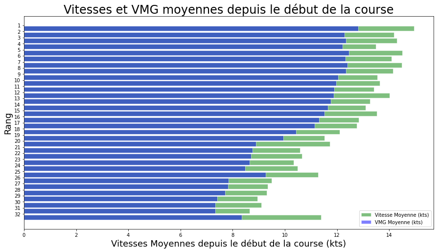

```python
df_4plot = df_rangvsvitesse.sort_values('Rang',ascending=False)
# libraries
import numpy as np
import matplotlib.pyplot as plt

plt.figure(figsize=(15,8))
# set width of bar
barWidth = 0.5

# set height of bar
bars1 = df_4plot['Vitesse moyenne']
bars2 = df_4plot['VMG moyenne']


# Set position of bar on X axis
r1 = np.arange(len(bars1))
r2 = [x for x in r1]

# Make the plot
plt.barh(r1, bars1, color='green', edgecolor='white', label='Vitesse Moyenne (kts)',alpha=0.5)
plt.barh(r2, bars2, color='blue', edgecolor='white', label='VMG Moyenne (kts)',alpha=0.5)

# Add xticks on the middle of the group bars
plt.xlabel('Vitesses Moyennes depuis le début de la course (kts)',size=18)
plt.ylabel('Rang',size=18)
plt.yticks([r + barWidth for r in range(len(bars1))], df_4plot['Rang'])

# Create legend & Show graphic
plt.legend()
plt.title('Vitesses et VMG moyennes depuis le début de la course',size=24)
plt.show()
```

### On se rend compte que le dernier a un mauvais ratio VMG/Vitesse depuis le début de la course. Il va vite mais est dernier car ayant du faire demi-tour pour faire réparer son voilier avant de repartir de zéro.

### A part ce cas particulier (Jérémie Beyou), le rang est globalement bien corrélé à la VMG moyenne.

# Impact de la présence d'un foil sur le classement

```python
df_rgvsfoil = df_perfvoilier[['Rang','Foils']].sort_values('Rang',ascending=False)
df_rgvsfoil.sort_values('Rang',ascending=True).T
```

| Skipper | Charlie Dalin | Thomas Ruyant | Kevin Escoffier | Jean Le Cam | Louis Burton | Yannick Bestaven | Sébastien Simon | Boris Herrmann | Damien Seguin | Giancarlo Pedote | ... | Didac Costa | Pip Hare | Fabrice Amedeo | Clément Giraud | Alexia Barrier | Miranda Merron | Ari Huusela | Kojiro Shiraishi | Sébastien Destremau | Jérémie Beyou |
| --- | --- | --- | --- | --- | --- | --- | --- | --- | --- | --- | --- | --- | --- | --- | --- | --- | --- | --- | --- | --- | --- |
| Rang | 1 | 2 | 3 | 4 | 5 | 6 | 7 | 8 | 9 | 10 | ... | 23 | 24 | 25 | 26 | 27 | 28 | 29 | 30 | 31 | 32 |
| Foils | 1 | 1 | 1 | 0 | 1 | 1 | 1 | 1 | 0 | 1 | ... | 0 | 0 | 1 | 0 | 0 | 0 | 0 | 1 | 0 | 1 |

2 rows × 30 columns

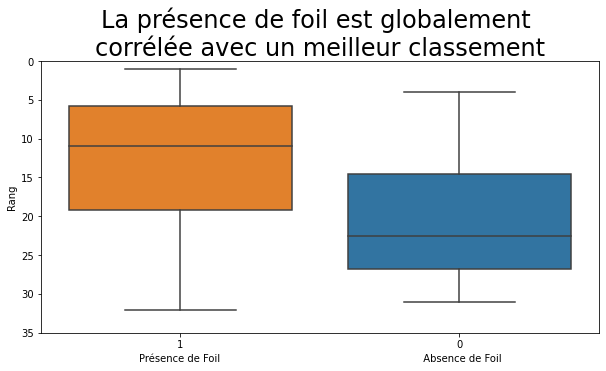

```python
# library & dataset
import seaborn as sns

plt.figure(figsize=(10,5))

sns.boxplot( x=df_perfvoilier["Foils"], y=df_perfvoilier["Rang"])
# sns.violinplot( x=df_perfvoilier["Foils"], y=df_perfvoilier["Rang"],width=0.3)
plt.ylim(35,0)
plt.xlim(1.5,-0.5)
plt.xlabel('Présence de Foil                                                                 Absence de Foil')
plt.title('La présence de foil est globalement \ncorrélée avec un meilleur classement',size=24)
```

# Classement en fonction des autres caractéristiques techniques des bateaux

##### Dans la partie ci-dessous, j'essaie de clusteriser les bateaux en fonction de leurs caractéristiques techniques uniquement et voir si certains sont "prédestinés à perdre" ou à gagner. J'ai essayé le DBSCAN qui n'a pas du tout marché (une classe avec les 2 premiers, une autre classe avec tous les autres), le KMEANS et le Affinity Propagation comme techniques de clustering.

```
##################################################################################
Le plus mauvais classement moyen correspond au cluster  1
##################################################################################
ETUDE DU CLASSEMENT DU POIDS
On constate que le kmeans a isolé un cluster correspondant aux bateaux de poids plus important
Poids moyens des bateaux du cluster "mal classé" :  8.79  tonnes
Poids moyen des bateaux hors cluster "mal classé" :  7.96  tonnes
Les bateaux du cluster "lourd" (mauvais classement) sont en moyenne plus lourds de 820.0 kilos, soit
en moyenne 10.0 % plus lourds que la moyenne des autres clusters.
##################################################################################
ETUDE DU CLASSEMENT EN FONCTION DE LA SURFACE DE VOILE AU PORTANT
On constate que le kmeans a isolé un cluster correspondant aux bateaux dont la surface de voile au portant est plus faible
Moyenne pour les bateaux du cluster "mal classé" :  590.0  m2
Moyenne pour les bateaux hors cluster "mal classé" :  589.0  m2
En moyenne, les bateaux du cluster mal classé ont  1.0 m2 de moins que les bateaux des autres clusters
```

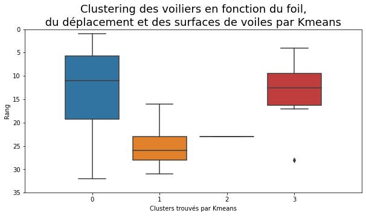

```python
# k-means clustering
from numpy import unique
from numpy import where
from sklearn.datasets import make_classification
from sklearn.cluster import KMeans
import matplotlib.pyplot as plt
from sklearn.preprocessing import StandardScaler
from sklearn.datasets import make_classification
from sklearn.cluster import DBSCAN

tmp = df_perfvoilier.reset_index()
tmp = tmp.drop(['Rang','Skipper','Date','DTL','Nat/Voile'],axis=1)

# tmp

scaler = StandardScaler()
df_perfvoilier_scaled = scaler.fit_transform(tmp)

#  #### CLUSTERING AVEC DBSCAN
# modeldbscan = DBSCAN(eps=0.0001, min_samples=0)
# # fit model and predict clusters
# yhat_dbscan = modeldbscan.fit_predict(df_perfvoilier_scaled)
# # retrieve unique clusters
# clustersdbscan = unique(yhat)

 #### CLUSTERING AVEC KMEANS
model = KMeans(n_clusters=4)
# fit the model
model.fit(df_perfvoilier_scaled)
# assign a cluster to each example
yhat_kmeans = model.predict(df_perfvoilier_scaled)
# retrieve unique clusters
clusterskmeans = unique(yhat_kmeans)

df_perfvoilier['Cluster_Kmeans'] = yhat_kmeans
# df_perfvoilier['Cluster_DBSCAN'] = yhat_dbscan


plt.figure(figsize=(10,5))
sns.boxplot( x=df_perfvoilier["Cluster_Kmeans"], y=df_perfvoilier["Rang"])
# sns.violinplot( x=df_perfvoilier["Foils"], y=df_perfvoilier["Rang"],width=0.3)
plt.ylim(35,0)
plt.xlim(-1,4)
plt.xlabel('Clusters trouvés par Kmeans')
plt.title('Clustering des voiliers en fonction du foil,\n du déplacement et des surfaces de voiles par Kmeans ',size=18)


rang_moyen_par_cluster=[]
for i in range(4):
    rangsmoyen_cluster = df_perfvoilier[df_perfvoilier['Cluster_Kmeans']==i]['Rang'].mean()
    rang_moyen_par_cluster.append(rangsmoyen_cluster)


poidsmoyen_clusterlourd = df_perfvoilier[df_perfvoilier['Cluster_Kmeans']==pd.Series(rang_moyen_par_cluster).idxmax()]['Déplacement (poids)'].mean()
poidsmoyen = df_perfvoilier[df_perfvoilier['Cluster_Kmeans']!=pd.Series(rang_moyen_par_cluster).idxmax()]['Déplacement (poids)'].mean()
diffpoids = round(poidsmoyen_clusterlourd - poidsmoyen,2)*1000

print('##################################################################################')
print('Le plus mauvais classement moyen correspond au cluster ' ,pd.Series(rang_moyen_par_cluster).idxmax())
print('##################################################################################')
print('ETUDE DU CLASSEMENT DU POIDS')
print('On constate que le kmeans a isolé un cluster correspondant aux bateaux de poids plus important')
print('Poids moyens des bateaux du cluster "mal classé" : ' , round(poidsmoyen_clusterlourd,2) , ' tonnes')
print('Poids moyen des bateaux hors cluster "mal classé" : ', round(poidsmoyen,2) , ' tonnes')
print('Les bateaux du cluster "lourd" (mauvais classement) sont en moyenne plus lourds de', diffpoids, 'kilos, soit\nen moyenne' , round(0.1*(diffpoids/poidsmoyen),0) , '% plus lourds que la moyenne des autres clusters.')
print('##################################################################################')

surfvoile_clusterbad = df_perfvoilier[df_perfvoilier['Cluster_Kmeans']==pd.Series(rang_moyen_par_cluster).idxmax()]['Surface de voiles au portant en m2'].mean()
surfvoilemoyenne = df_perfvoilier[df_perfvoilier['Cluster_Kmeans']!=pd.Series(rang_moyen_par_cluster).idxmax()]['Surface de voiles au portant en m2'].mean()
diffsurf = round(surfvoile_clusterbad - surfvoilemoyenne,2)

print('ETUDE DU CLASSEMENT EN FONCTION DE LA SURFACE DE VOILE AU PORTANT')
print('On constate que le kmeans a isolé un cluster correspondant aux bateaux dont la surface de voile au portant est plus faible')
print('Moyenne pour les bateaux du cluster "mal classé" : ' , round(surfvoile_clusterbad,0) , ' m2')
print('Moyenne pour les bateaux hors cluster "mal classé" : ' , round(surfvoilemoyenne,0) , ' m2')
print('En moyenne, les bateaux du cluster mal classé ont ', round(abs(diffsurf),0), 'm2 de moins que les bateaux des autres clusters')
```

### On a ainsi montré que les facteurs discriminants sont l'absence de foil et un poids élevé. La surface de voile au portant ne semble pas déterminante

### Le DBSCAN à moins de mettre des paramètres extrêmes, n'a pas été capable de classifier autrement qu'avec 2 classes. Les 2 premiers dans un groupe, et le reste dans l'autre

### Je constate que dans les deux algorithmes de clustering qui ont "marché" (produit un résultat), il se dégage une classe qui correspond aux bateaux au déplacement (poids) le plus élevé.

### On peut donc en conclure que l'absence de foil et un déplacement (poids) élevé sont potentiellement handicapants.

```
##################################################################################
Le plus mauvais classement moyen correspond au cluster  1
##################################################################################
ETUDE DU CLASSEMENT DU POIDS
On constate que le kmeans a isolé un cluster correspondant aux bateaux de poids plus important
Poids moyens des bateaux du cluster "mal classé" :  8.9  tonnes
Poids moyen des bateaux hors cluster "mal classé" :  8.01  tonnes
Les bateaux du cluster "lourd" (mauvais classement) sont en moyenne plus lourds de 890.0 kilos, soit
en moyenne 11.0 % plus lourds que la moyenne des autres clusters.
##################################################################################
ETUDE DU CLASSEMENT EN FONCTION DE LA SURFACE DE VOILE AU PORTANT
On constate que le kmeans a isolé un cluster correspondant aux bateaux dont la surface de voile au portant est plus faible
Moyenne pour les bateaux du cluster "mal classé" :  590.0  m2
Moyenne pour les bateaux hors cluster "mal classé" :  589.0  m2
En moyenne, les bateaux du cluster mal classé ont  1.0 m2 de différence que les bateaux des autres clusters
```

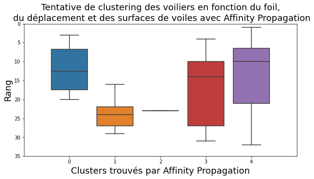

```python
from sklearn.cluster import AffinityPropagation

modelaffinitypropag = AffinityPropagation(damping=0.85)
modelaffinitypropag.fit(df_perfvoilier_scaled)
yhat_affpropag = modelaffinitypropag.predict(df_perfvoilier_scaled)

df_perfvoilier['Cluster_AffinityPropag'] = yhat_affpropag

plt.figure(figsize=(10,5))

sns.boxplot( x=df_perfvoilier["Cluster_AffinityPropag"], y=df_perfvoilier["Rang"])
plt.ylim(35,0)
plt.xlim(-1,5)
plt.xlabel('Clusters trouvés par Affinity Propagation',size=18)
plt.ylabel('Rang',size=18)
plt.title('Tentative de clustering des voiliers en fonction du foil,\n du déplacement et des surfaces de voiles avec Affinity Propagation',size=18)

rang_moyen_par_cluster=[]
for i in range(4):
    rangsmoyen_cluster = df_perfvoilier[df_perfvoilier['Cluster_AffinityPropag']==i]['Rang'].mean()
    rang_moyen_par_cluster.append(rangsmoyen_cluster)


poidsmoyen_clusterlourd = df_perfvoilier[df_perfvoilier['Cluster_AffinityPropag']==pd.Series(rang_moyen_par_cluster).idxmax()]['Déplacement (poids)'].mean()
poidsmoyen = df_perfvoilier[df_perfvoilier['Cluster_AffinityPropag']!=pd.Series(rang_moyen_par_cluster).idxmax()]['Déplacement (poids)'].mean()
diffpoids = round(poidsmoyen_clusterlourd - poidsmoyen,2)*1000

print('##################################################################################')
print('Le plus mauvais classement moyen correspond au cluster ' ,pd.Series(rang_moyen_par_cluster).idxmax())
print('##################################################################################')
print('ETUDE DU CLASSEMENT DU POIDS')
print('On constate que le kmeans a isolé un cluster correspondant aux bateaux de poids plus important')
print('Poids moyens des bateaux du cluster "mal classé" : ' , round(poidsmoyen_clusterlourd,2) , ' tonnes')
print('Poids moyen des bateaux hors cluster "mal classé" : ', round(poidsmoyen,2) , ' tonnes')
print('Les bateaux du cluster "lourd" (mauvais classement) sont en moyenne plus lourds de', diffpoids, 'kilos, soit\nen moyenne' , round(0.1*(diffpoids/poidsmoyen),0) , '% plus lourds que la moyenne des autres clusters.')
print('##################################################################################')

surfvoile_clusterbad = df_perfvoilier[df_perfvoilier['Cluster_Kmeans']==pd.Series(rang_moyen_par_cluster).idxmax()]['Surface de voiles au portant en m2'].mean()
surfvoilemoyenne = df_perfvoilier[df_perfvoilier['Cluster_Kmeans']!=pd.Series(rang_moyen_par_cluster).idxmax()]['Surface de voiles au portant en m2'].mean()
diffsurf = round(surfvoile_clusterbad - surfvoilemoyenne,2)

print('ETUDE DU CLASSEMENT EN FONCTION DE LA SURFACE DE VOILE AU PORTANT')
print('On constate que le kmeans a isolé un cluster correspondant aux bateaux dont la surface de voile au portant est plus faible')
print('Moyenne pour les bateaux du cluster "mal classé" : ' , round(surfvoile_clusterbad,0) , ' m2')
print('Moyenne pour les bateaux hors cluster "mal classé" : ' , round(surfvoilemoyenne,0) , ' m2')
print('En moyenne, les bateaux du cluster mal classé ont ', round(diffsurf,0), 'm2 de différence que les bateaux des autres clusters')
```

##### Ce cluster donne les mêmes résultats que le précédent, c'est à dire qu'il identifie les bateaux lourds parmis les mal classés.

## Conclusion: Des caractéristiques techniques optimales seraient donc :

## - Un déplacement (poids) faible

# Visualisation de la distance parcourue par voilier.

```python
from ipyleaflet import Map, basemaps, basemap_to_tiles,ScaleControl,Polyline,LegendControl,Marker

# add map and options
m = Map(basemap=basemaps.OpenTopoMap,
        center=(df_course['Latitude'].median(),df_course['Longitude'].median()),
        zoom=1.5,
       box_zoom = True,
       scroll_wheel_zoom = True,
       inertia=True)

m.add_control(ScaleControl(position='bottomleft'))

# create a zip of colors and skipper name to associate one skipper to a color
colors = []
n = len(df_course['Skipper'].unique())
for i in range(n):
    colors.append('#%06X' % randint(0, 0xFFFFFF))

# make a for loop to display one line per skipper with a unique column

for pair in zip(liste_skippers_par_ordre, colors):
# for pair in zip(df_course['Skipper'].unique(), colors):
    tmp = df_course[df_course['Skipper'] == pair[0]][['Latitude','Longitude']]
    subset = tmp[['Latitude', 'Longitude']]
    positions = [list(x) for x in subset.to_numpy()]
    line = Polyline(locations=positions,fill=False,weight=1,color=pair[1])
    m.add_layer(line)

# create and display legend
leg = {}
i = 0
for pair in zip(liste_skippers_par_ordre, colors):
    i = i+1
    tmpi=str(i) + ' - ' + pair[0]
    leg[tmpi] = pair[1]
#     leg[i+pair[0])] = pair[1]

legend = LegendControl(leg,position='topright')
legend.name = "Trajectoire des voiliers"
m.add_control(legend)

m
```

```python
m.save('TrajectoireDesVoiliers.html', title='Trajectoire Des Voiliers')
```

# Analyses en série temporelles

## Evolution du classement

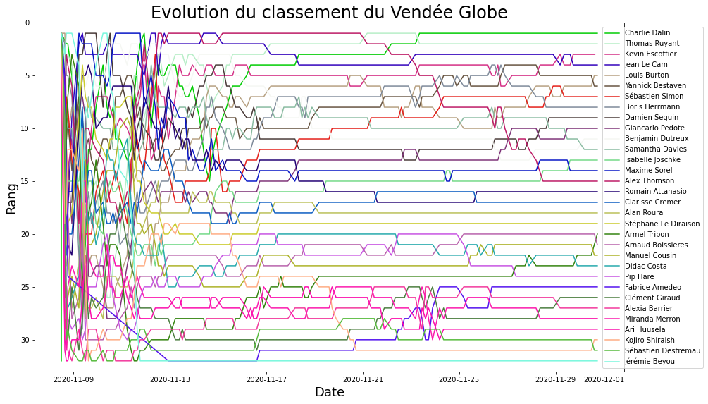

```python
df_tempseries = df_course.set_index('Date')
plt.figure(figsize=(15,9.1))
plt.ylim(33,0)

for pair in zip(liste_skippers_par_ordre, colors):
    plt.plot(df_tempseries[df_tempseries['Skipper']== pair[0]]['Rang'],label=pair[0],color=pair[1])#,linestyle='dotted')

plt.legend(loc=7,bbox_to_anchor=(1.14, 0.4989))
plt.title('Evolution du classement du Vendée Globe',size=24)
plt.xlabel('Date',size=18)
plt.ylabel('Rang',size=18)
plt.show()
```

### Il y a beaucoup de changements dans la classement surtout la première semaine, puis cela se tasse. Il continue à y avoir du changement pour certains bateaux qui sont assez proches.

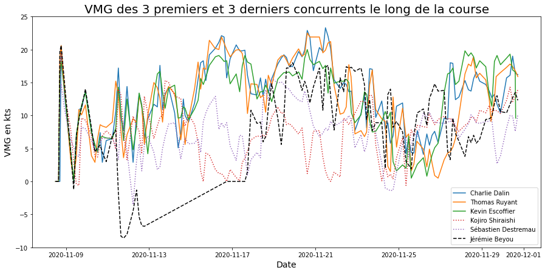

```python
df_tempseries = df_course.set_index('Date')

plt.figure(figsize=(15,7))
plt.ylim(-10,25)

# plot des premiers
for skip in liste_skippers_par_ordre[0:3]:
    plt.plot(df_tempseries[df_tempseries['Skipper']== skip]['VMG'],label= skip)#,linestyle='dotted')

# plot des derniers
for skip in liste_skippers_par_ordre[-3:-1]:
    plt.plot(df_tempseries[df_tempseries['Skipper']== skip]['VMG'],label=skip,linestyle='dotted')

# plot de Jérémie Beyou
plt.plot(df_tempseries[df_tempseries['Skipper']== 'Jérémie Beyou']['VMG'],label='Jérémie Beyou',linestyle='--',color='black')

plt.xlabel('Date',size=14)
plt.ylabel('VMG en kts',size=14)
plt.title('VMG des 3 premiers et 3 derniers concurrents le long de la course',size=20)
plt.legend()
plt.show()
```

### Sur ce graphique, on constate que Jérémie Beyou a subi un très lourd retard suite à son problème technique. On voit qu'il a du faire demi-tour entre le 10 et le 17 Novembre. Il est ensuite reparti le 18 Novembre mais il le rattrape en partie grace à des performances parfois supérieures aux premiers du classement.

# Le profil des vitesses de Jérémie Beyou

### Jérémie Beyou a d’abord eu un problème avec la cadène de renvoi de point d’écoute de voiles d’avant, qui « a fait exploser la cloison de barre d’écoute » puis le bateau a percuté un ofni (objet flottant non identifié), ce qui a endommagé le safran tribord. Continuant sa course face à un front violent, « le courant de bastaque » (pièce de maintien du mât) a explosé. (Source: 20 minutes)

### Il a du faire demi-tour pour faire réparer son bateau avant de repartir. Mais il est en train de refaire son retard sur les autres concurrents avec un profil de vitesses correspondant plus à un milieu de classement qu'à un dernier.

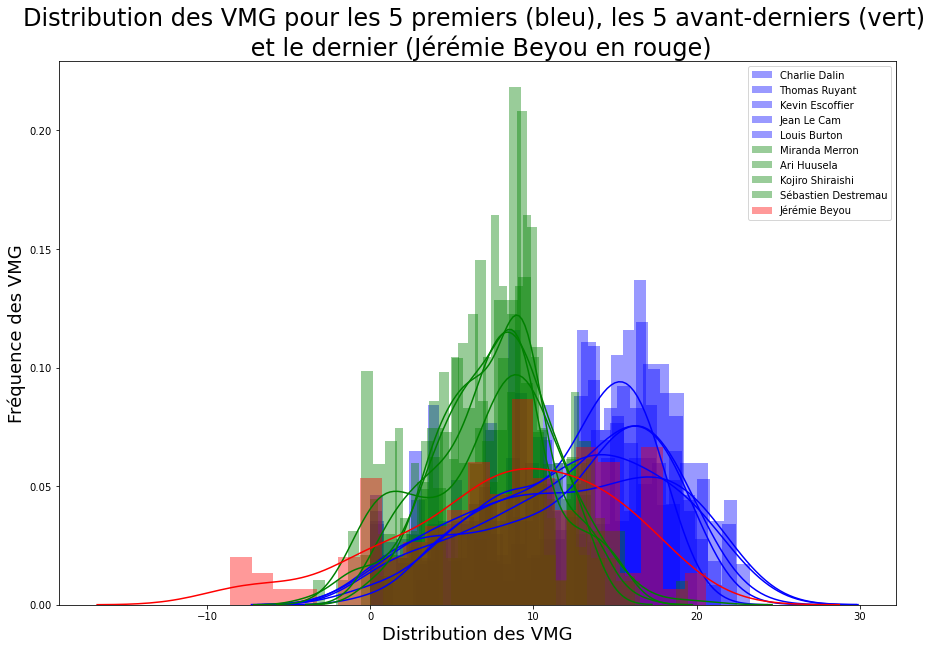

```python
plt.figure(figsize=(15,10))

v = len(df_classement)
alphadesc=0
for skip in liste_skippers_par_ordre[0:5]:
    alphadesc = alphadesc+1/(v+1)
    a = 1-alphadesc
    vel = df_course[df_course['Skipper']==skip]['VMG']
    moving_average = uniform_filter1d(vel, size=3)
#     sns.regplot(x=24600-df[df['Skipper']==skip]['DTF'],y=moving_average,fit_reg=True,scatter_kws={'alpha':0.7},label=skip)
#     sns.regplot(x=24600-df[df['Skipper']==skip]['DTF'], y=vel-moving_average,fit_reg=True,scatter_kws={'alpha':0.7},label=skip)
#     sns.regplot(x=vel,y=vel-moving_average,fit_reg=True,scatter_kws={'alpha':0.4},label=skip)
#     sns.regplot(x=vel-moving_average,y=vel,fit_reg=True,scatter_kws={'alpha':0.4},label=skip)
#     plt.plot(sorted(vel-moving_average),label=skip)
    sns.distplot(vel, bins=len(vel)//5, label=skip,kde_kws={'alpha':1},color='blue')

for skip in liste_skippers_par_ordre[v-5:v-1]:
    alphadesc = alphadesc+1/(v+1)
    a = 1-alphadesc
    vel = df_course[df_course['Skipper']==skip]['VMG']
    moving_average = uniform_filter1d(vel, size=3)
    sns.distplot(vel, bins=len(vel)//5, label=skip,kde_kws={'alpha':1},color='green')


skip = liste_skippers_par_ordre[-1]
vel = df_course[df_course['Skipper']==skip]['VMG']
moving_average = uniform_filter1d(vel, size=3)
sns.distplot(vel, bins=len(vel)//5, label=skip,kde_kws={'alpha':1},color='red')


plt.xlabel('Distribution des VMG',size=18)
# plt.xlabel('VMG - MovingAverage(VMG)')
plt.ylabel('Fréquence des VMG',size=18)
plt.legend()
plt.title('Distribution des VMG pour les 5 premiers (bleu), les 5 avant-derniers (vert) \n et le dernier (Jérémie Beyou en rouge)',size=24)
plt.show()
```

### Jérémie Beyou est un cas spécifique, il a été pénalisé par un problème qui l'a rétrogradé en dernière position. Par contre, son spectre de VMG correspond plutôt à un milieu de classement. Ce qui signifie qu'il est en train de rattraper son retard sur les derniers concurrents et qu'il est possible qu'il remonte au classement.

## Est-ce que les fluctuations de VMG sont déterminantes dans le classement ?

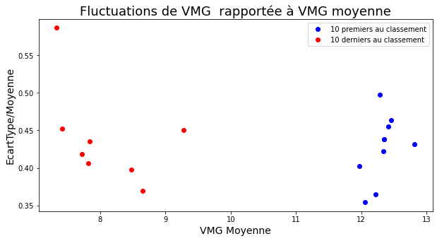

```python
plt.figure(figsize=(10,5))

moyennes=[]
ecart_types=[]
for skip in liste_skippers_par_ordre[0:10]:
    moy=np.mean(df_course[df_course['Skipper']==skip]['VMG'])
    ect = np.std(df_course[df_course['Skipper']==skip]['VMG'])
    moyennes.append(moy)
    ecart_types.append(ect)

plt.scatter(moyennes,np.divide(ecart_types,moyennes),color='b',label = '10 premiers au classement')

moyennes2=[]
ecart_types2=[]
for skip in liste_skippers_par_ordre[-10:-2]:
    moy=np.mean(df_course[df_course['Skipper']==skip]['VMG'])
    ect = np.std(df_course[df_course['Skipper']==skip]['VMG'])
    moyennes2.append(moy)
    ecart_types2.append(ect)

plt.scatter(moyennes2,np.divide(ecart_types2,moyennes2),color='r',label = '10 derniers au classement')

plt.xlabel('VMG Moyenne',size=14)
plt.ylabel('EcartType/Moyenne',size=14)
plt.legend()
plt.title('Fluctuations de VMG  rapportée à VMG moyenne',size=18)
plt.show()
```

### L'idée était de voir si les mieux classés étaient les plus "consistents" en terme de VMG. Mais nous pouvons voir que la différence entre un bon classement et un mauvais classement réside essentiellement dans la différence de VMG moyenne.

```python
end = time.time()
print('The notebook took ' , round(end-start,0) , ' seconds to run')
```

```
The notebook took  20.0  seconds to run
```